# Cluster analysis - Juan Luis Polo

Importing dataset *buddymove_holidayiq.csv*.

```r
buddymove.df <- read.csv("buddymove_holidayiq.csv")

head(buddymove.df)
```

|  | User.Id | Sports | Religious | Nature | Theatre | Shopping | Picnic |
| --- | --- | --- | --- | --- | --- | --- | --- |
| 1 | User 1 | 2 | 77 | 79 | 69 | 68 | 95 |
| 2 | User 2 | 2 | 62 | 76 | 76 | 69 | 68 |
| 3 | User 3 | 2 | 50 | 97 | 87 | 50 | 75 |
| 4 | User 4 | 2 | 68 | 77 | 95 | 76 | 61 |
| 5 | User 5 | 2 | 98 | 54 | 59 | 95 | 86 |
| 6 | User 6 | 3 | 52 | 109 | 93 | 52 | 76 |

```r
summary(buddymove.df)
```

```
     User.Id        Sports        Religious         Nature         Theatre
 User 1  :  1   Min.   : 2.00   Min.   : 50.0   Min.   : 52.0   Min.   : 59.0
 User 10 :  1   1st Qu.: 6.00   1st Qu.: 84.0   1st Qu.: 89.0   1st Qu.: 93.0
 User 100:  1   Median :12.00   Median :104.0   Median :119.0   Median :113.0
 User 101:  1   Mean   :11.99   Mean   :109.8   Mean   :124.5   Mean   :116.4
 User 102:  1   3rd Qu.:18.00   3rd Qu.:132.0   3rd Qu.:153.0   3rd Qu.:138.0
 User 103:  1   Max.   :25.00   Max.   :203.0   Max.   :318.0   Max.   :213.0
 (Other) :243
    Shopping         Picnic
 Min.   : 50.0   Min.   : 61.0
 1st Qu.: 79.0   1st Qu.: 92.0
 Median :104.0   Median :119.0
 Mean   :112.6   Mean   :120.4
 3rd Qu.:138.0   3rd Qu.:143.0
 Max.   :233.0   Max.   :218.0
```

```r
str(buddymove.df)
```

```
'data.frame':   249 obs. of  7 variables:
 $ User.Id  : Factor w/ 249 levels "User 1","User 10",..: 1 112 173 184 195 206 217 228 239 2 ...
 $ Sports   : int  2 2 2 2 2 3 3 3 3 3 ...
 $ Religious: int  77 62 50 68 98 52 64 54 64 86 ...
 $ Nature   : int  79 76 97 77 54 109 85 107 108 76 ...
 $ Theatre  : int  69 76 87 95 59 93 82 92 64 74 ...
 $ Shopping : int  68 69 50 76 95 52 73 54 54 74 ...
 $ Picnic   : int  95 68 75 61 86 76 69 76 93 103 ...
```

#### Part A

Scaling the attributes in the dataset, since it is a prerrequisite to run k-means algorithm later. Function *scale* set attribute type to numeric, which is another prerrequiasite for running a kmeans algorithm.

```r
bm.scaled <- scale(buddymove.df[,-1])
```

In order to study to optimal number of clusters, fviz_nbclust function has been used, which plots the total within-cluster sum of squares (wss).

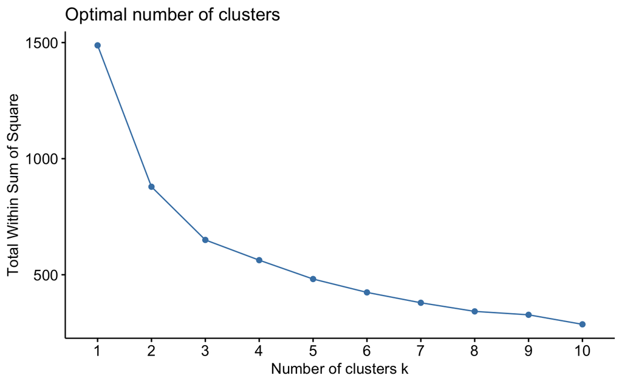

```r
library(cluster)
library(factoextra)
fviz_nbclust(bm.scaled, kmeans, method="wss")
```

In the above figure (WSS elbow), it can be observed that the values of TWSS get stable after 7 clusters.

#### Part B

Function *fviz_cluster* will has been used to visualize the result of K-Means in a 2 dimention plot. It has been tested for the following number of clusters: 7, 8, 9.

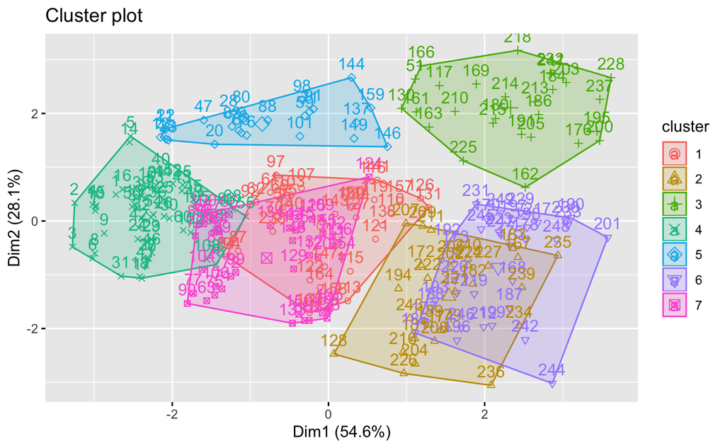

```r
set.seed(1122)
kmeans.7 <- kmeans(bm.scaled, centers = 7, nstart = 50)
kmeans.8 <- kmeans(bm.scaled, centers = 8, nstart = 50)
kmeans.9 <- kmeans(bm.scaled, centers = 9, nstart = 50)
bm.cluster7 <- fviz_cluster(kmeans.7, bm.scaled)
bm.cluster8 <- fviz_cluster(kmeans.8, bm.scaled)
bm.cluster9 <- fviz_cluster(kmeans.9, bm.scaled)
bm.cluster7
```

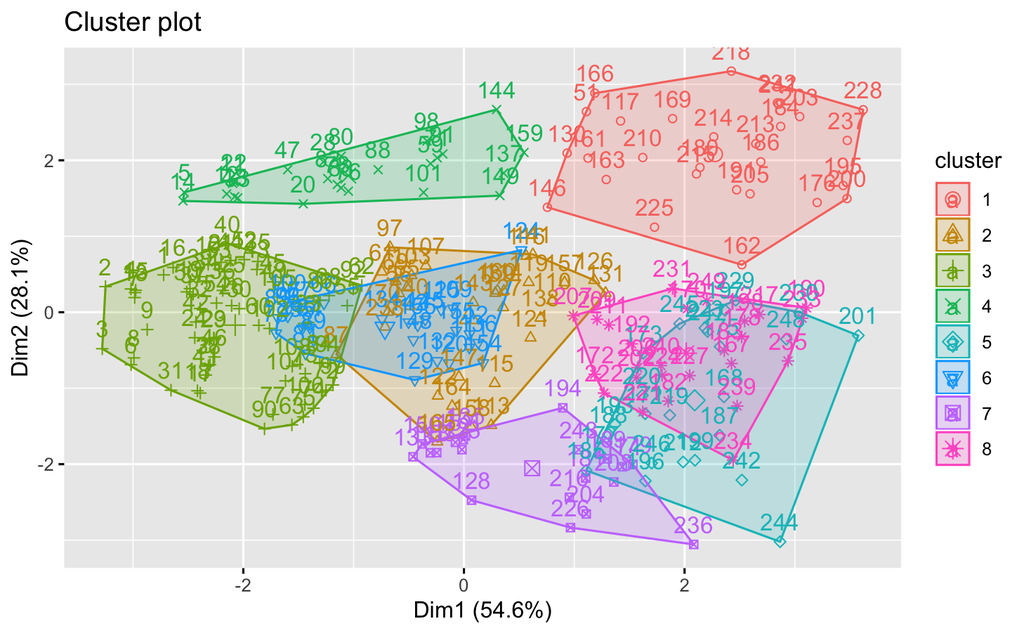

```r
bm.cluster8
```

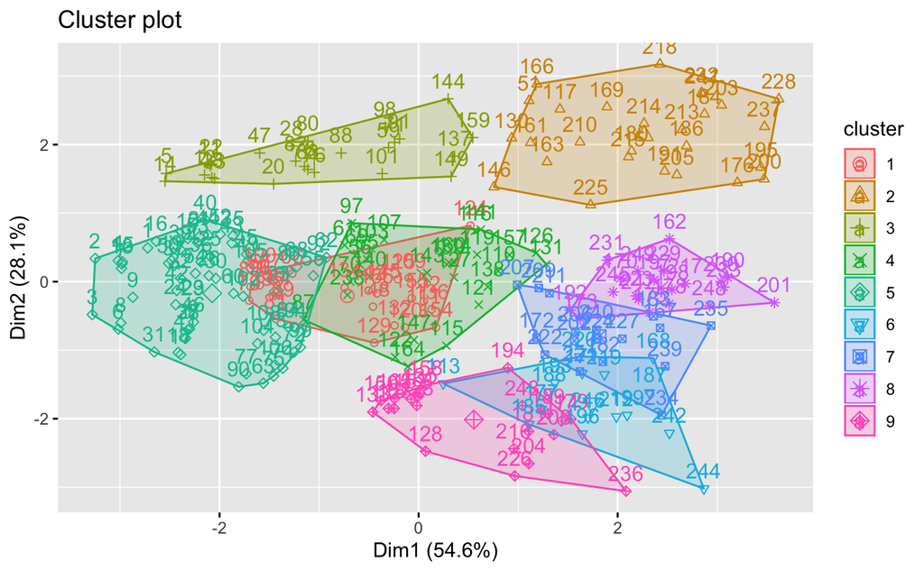

```r
bm.cluster9
```

Function fviz_cluster() runs a PCA of the dataset in order to shown a 2-D plot of the clusters. It can be noticed that the two selected variables explain the 54.6% and 28.1% of the variance in the data respectively. The sum of the variance explained by both variables is very high, which means that this graph collects much of the information from the model.

Taking into account the WSS represented in Part A, and the plots in this Part, it has been chosen to study the following Parts for 8 clusters

#### Part C

Calculating the number of observations in each cluster por the 8-cluster configuration. The number of observations for each cluster are showed in decreasing order:

```r
cat("Number of observations in each cluster: ", kmeans.8$size, "\n")
```

```
Number of observations in each cluster:  28 32 66 25 25 27 20 26
```

```r
cat("Number of observations in each cluster sorted in decreasing order: ",
    sort(kmeans.8$size, decreasing = T), "\n")
```

```
Number of observations in each cluster sorted in decreasing order:  66 32 28 27 26 25 25 20
```

#### Part D

Obtaining the total SSE of the selected clusters:

```r
kmeans.8$tot.withinss
```

```
[1] 339.8719
```

#### Part E

Obtaining the SSE of each cluster:

```r
kmeans.8$withinss
```

```
[1] 46.64266 45.03722 77.67789 31.62487 49.85852 29.17725 19.66855 40.18490
```

#### Part F

Defining a list with the information of each cluster:

```r
clusters <- list()

for (i in 1:8) {
  clusters[[i]] <- bm.scaled[which(kmeans.8$cluster==i), ]
}
```

Plotting the boxplots for each cluster:

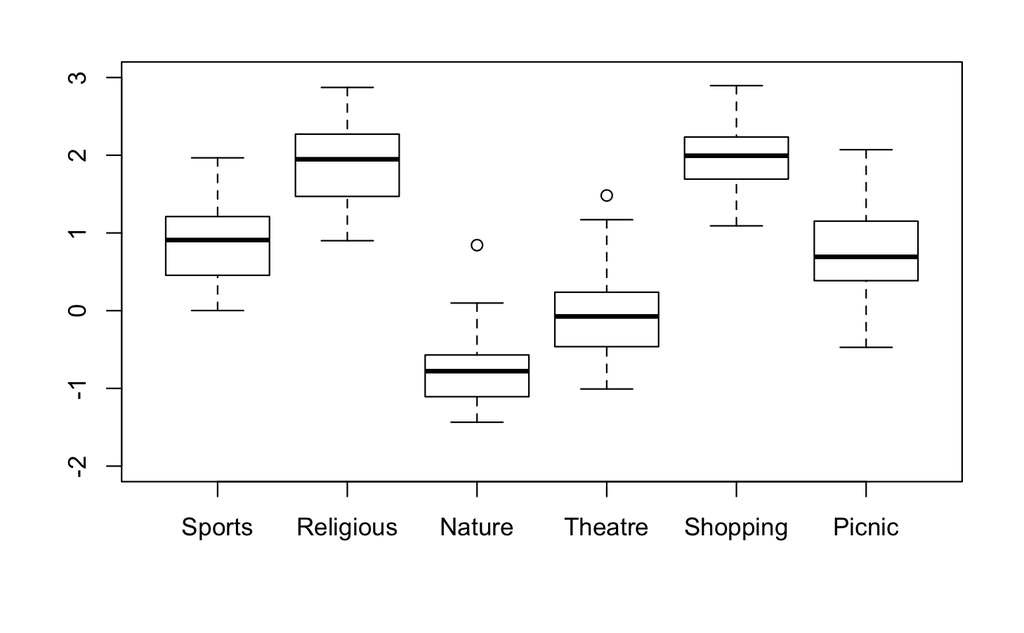

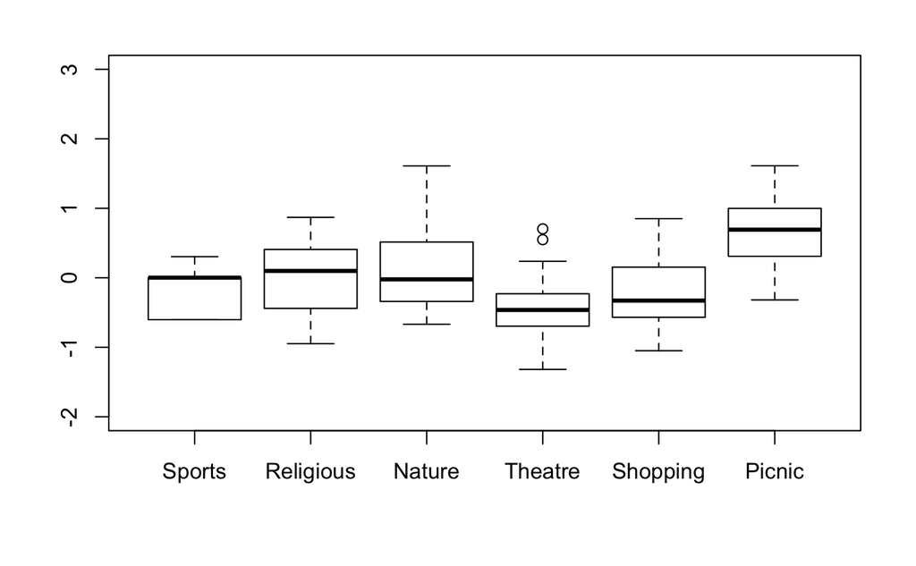

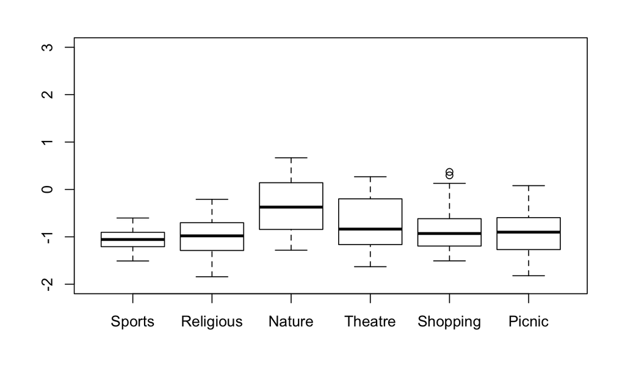

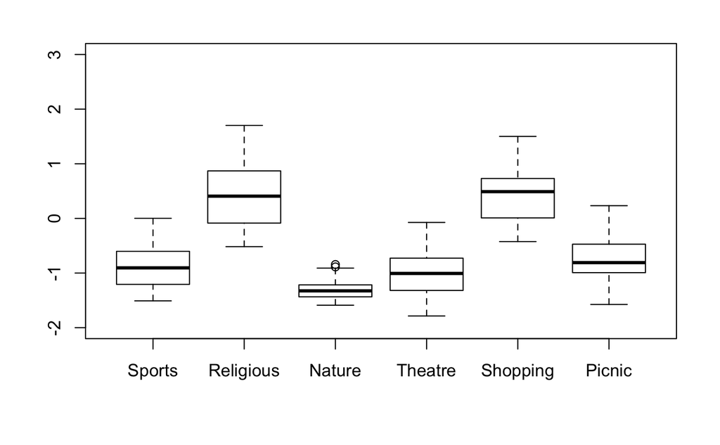

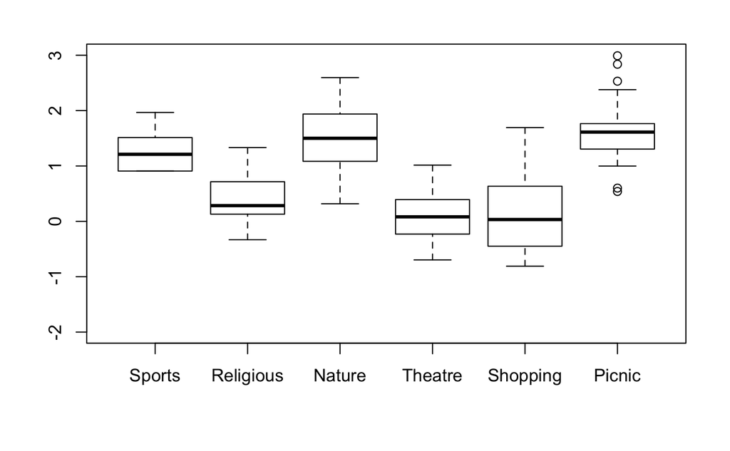

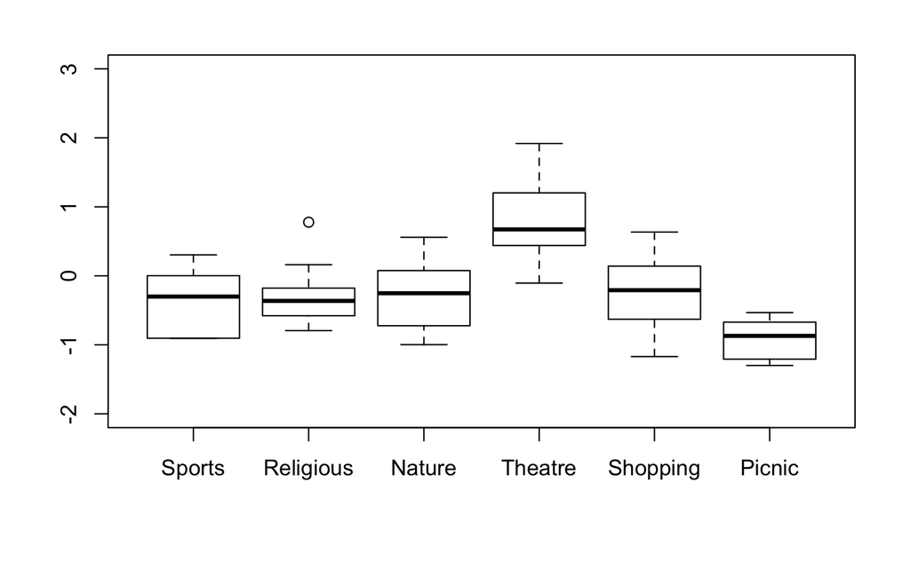

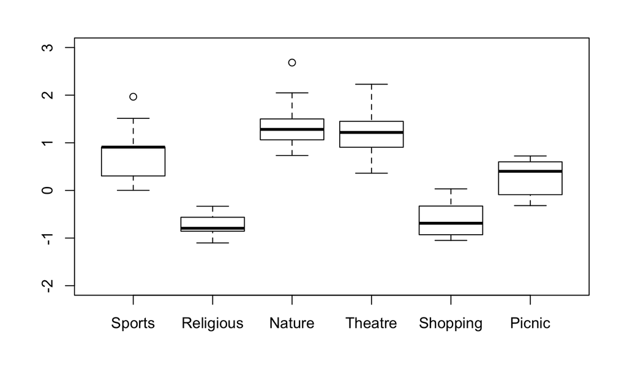

```r
for (i in 1:8) {
  boxplot(clusters[[i]], ylim=c(-2, 3))
  dim(clusters[[i]])[1]
}
```

[figure not shown]

```r
NA
```